# IE 582 Statistical Learning for Data Mining - Homework 3

Can Hakan Dagidir

# Homework Description

I have chosen 4 datasets and will try to make predictions with 4 different approaches. Then compare them and try to explain which properties of the datasets affected the performance of the different algorithms and what specific modifications were needed for different approaches

#### DATASET 1:

##### Student Performance

[Web Page](https://archive.ics.uci.edu/ml/datasets/Student+Performance)

Dataset has personal and grades data of students from math and portuguese language courses. We will be only using Portuguese grades of the students. To make things harder we will not use the other exam grades of the students but we will only focus on personal information about students.

Dataset has multiclass, binary and continuous attributes. We will approach the dataset with regression.

#### DATASET 2:

##### Breast Cancer

[Web Page](https://archive.ics.uci.edu/ml/datasets/Breast+Cancer+Wisconsin+%28Original%29)

This breast cancer databases was obtained from the University of Wisconsin Hospitals, Madison from Dr. William H. Wolberg.

We have medical information about the cell with anomaly. All attributes except the target one is continuous. We will approach the dataset with classification: Malign or Benign.

#### DATASET 3:

##### Online News Popularity

[Web Page](https://archive.ics.uci.edu/ml/datasets/Online+News+Popularity#)

This dataset contains many continuous and binary attributes. We will try to predict the number of shares the article will get via regression.

#### DATASET 4:

##### Polish Companies Bankruptcy

[Web Page](http://archive.ics.uci.edu/ml/datasets/Polish+companies+bankruptcy+data)

This dataset contains all continuous attributes about companies and their status. (Bankrupted or Not)

# Data Preperation

We load the required libraries and read the datasets first.

```r
require(glmnet)
require(ggplot2)
require(data.table)
require(glmnet)
require(rpart)
require(rattle)
require(skimr)
require(tidyverse)
require(dplyr)
require(caret)
library(maptree)
library(ranger)
library(e1071)
library(gbm)

# Reading data
data_1 <- read.csv2("/Users/canhakan/Desktop/IE 582/hw4/Student Performance Data Set /student-por.csv", header = TRUE)
data_2 <-read.csv("/Users/canhakan/Desktop/IE 582/hw4/Breast Cancer Wisconsin (Original)/wdbc.data", header = FALSE)
data_3 <- read.csv("/Users/canhakan/Desktop/IE 582/hw4/OnlineNewsPopularity/OnlineNewsPopularity.csv", header = T)
data_4 <- read.csv("/Users/canhakan/Desktop/IE 582/hw4/Polish companies bankruptcy data/data/4year.csv", header = T)

###
```

Then we do necessary modifications in the datasets.

```r
# Changing the multiclass attribute to different binomial attributes for Penalized Regression Approach
data_org_1 <- data_1 #Backing up the data.
data_1 = data_org_1  %>%
    mutate(MTeacher = ifelse(Mjob == 'teacher', 1, 0)) %>%
    mutate(MHealth = ifelse(Mjob == 'health', 1, 0)) %>%
    mutate(MServices = ifelse(Mjob == 'services', 1, 0)) %>%
    mutate(MOther = ifelse(Mjob == 'other', 1, 0)) %>%
    mutate(MAthome = ifelse(Mjob == 'at_home', 1, 0))  %>%
    mutate(FTeacher = ifelse(Fjob == 'teacher', 1, 0)) %>%
    mutate(FHealth = ifelse(Fjob == 'health', 1, 0)) %>%
    mutate(FServices = ifelse(Fjob == 'services', 1, 0)) %>%
    mutate(FOther = ifelse(Fjob == 'other', 1, 0)) %>%
    mutate(FAthome = ifelse(Fjob == 'at_home', 1, 0))  %>%
    # reasonhome reasonreputation reasoncourse reasonother
    mutate(reasonhome = ifelse(reason == 'home',1, 0))  %>%
    mutate(reasonreputation = ifelse(reason == 'reputation',1, 0))  %>%
    mutate(reasoncourse = ifelse(reason == 'course',1, 0))  %>%
    mutate(reasonother = ifelse(reason == 'other',1, 0))  %>%
    select(-Mjob,-Fjob,-reason) %>%
    # Also removing G2 and G3 for dataset to be harder. We will predict students 1st exam grades without having another exam data
    select(-G2,-G3)

### removing unnecessary columns
data_org_3 <- data_3
data_3  <- data_org_3  %>% select(-url,-timedelta)
###
```

We create a fit control function for general use

```r
# Creating common fit control
fit_control = trainControl(method = "repeatedcv",
                           number = 5,
                           repeats = 10)
```

# Student Performance Data

We first split our data to train and test parts.

```r
# DATA 1 splitting
set.seed(1)
# test-train index
index_1 <- createDataPartition(y = data_1$G1, p = .75, list = FALSE)
# create the split
data_train_1 <- data_1[index_1,]
data_test_1 <- data_1[-index_1,]
```

## Penalized Regression

```r
# Penalized Regression Approach - DATA 1
set.seed(1)
grid_pra_1 <- expand.grid(lambda = c(1,0.5,0.1,0.05,0.01), alpha=1)

pra_fit_1 <- train(G1 ~ .,
                 data = data_train_1,
                 method = "glmnet",
                 tuneGrid = grid_pra_1,
                 trControl = fit_control,
                  preProcess=c("center","scale"))
```

```r
pra_fit_1
```

```
## glmnet
##
## 488 samples
##  41 predictor
##
## Pre-processing: centered (42), scaled (42)
## Resampling: Cross-Validated (5 fold, repeated 10 times)
## Summary of sample sizes: 390, 391, 390, 390, 391, 391, ...
## Resampling results across tuning parameters:
##
##   lambda  RMSE      Rsquared   MAE
##   0.01    2.324274  0.2890719  1.798336
##   0.05    2.295097  0.2991362  1.775283
##   0.10    2.293544  0.2996493  1.776137
##   0.50    2.463269  0.2547535  1.949105
##   1.00    2.691915  0.1627538  2.165417
##
## Tuning parameter 'alpha' was held constant at a value of 1
## RMSE was used to select the optimal model using the smallest value.
## The final values used for the model were alpha = 1 and lambda = 0.1.
```

## Decision Tree

```r
set.seed(1)
# DATA 1 DECISION TREE

# we create our grid with 5 complexity parameters
# we do min # of instances at terminal node by hand because the tuneGrid of rpart does not support it.

grid_dt_1 <- expand.grid(cp = c(0.0001,0.0025,0.005,0.0075,0.01))

dt_fit_1_10 <- train(G1 ~ .,
                 data = data_train_1,
                 method = "rpart",
                 tuneGrid = grid_dt_1,
                 control = rpart.control(minbucket=c(10)),
                 trControl = fit_control)

dt_fit_1_20 <- train(G1 ~ .,
                 data = data_train_1,
                 method = "rpart",
                 tuneGrid = grid_dt_1,
                 control = rpart.control(minbucket=c(20)),
                 trControl = fit_control)

dt_fit_1_30 <- train(G1 ~ .,
                 data = data_train_1,
                 method = "rpart",
                 tuneGrid = grid_dt_1,
                 control = rpart.control(minbucket=c(30)),
                 trControl = fit_control)

dt_fit_1_40 <- train(G1 ~ .,
                 data = data_train_1,
                 method = "rpart",
                 tuneGrid = grid_dt_1,
                 control = rpart.control(minbucket=c(40)),
                 trControl = fit_control)

dt_fit_1_50 <- train(G1 ~ .,
                 data = data_train_1,
                 method = "rpart",
                 tuneGrid = grid_dt_1,
                 control = rpart.control(minbucket=c(50)),
                 trControl = fit_control)
```

```r
dt_fit_1_10
```

```
## CART
##
## 488 samples
##  41 predictor
##
## No pre-processing
## Resampling: Cross-Validated (5 fold, repeated 10 times)
## Summary of sample sizes: 390, 391, 390, 390, 391, 391, ...
## Resampling results across tuning parameters:
##
##   cp      RMSE      Rsquared   MAE
##   0.0001  2.539018  0.1954946  1.979391
##   0.0025  2.536683  0.1964930  1.978484
##   0.0050  2.528585  0.1979793  1.972051
##   0.0075  2.507065  0.2032372  1.953238
##   0.0100  2.485939  0.2082458  1.937158
##
## RMSE was used to select the optimal model using the smallest value.
## The final value used for the model was cp = 0.01.
```

```r
dt_fit_1_20
```

```
## CART
##
## 488 samples
##  41 predictor
##
## No pre-processing
## Resampling: Cross-Validated (5 fold, repeated 10 times)
## Summary of sample sizes: 391, 391, 389, 390, 391, 390, ...
## Resampling results across tuning parameters:
##
##   cp      RMSE      Rsquared   MAE
##   0.0001  2.441310  0.2240617  1.892576
##   0.0025  2.441310  0.2240617  1.892576
##   0.0050  2.440245  0.2243268  1.891854
##   0.0075  2.434453  0.2258723  1.887009
##   0.0100  2.432413  0.2240748  1.884898
##
## RMSE was used to select the optimal model using the smallest value.
## The final value used for the model was cp = 0.01.
```

```r
dt_fit_1_30
```

```
## CART
##
## 488 samples
##  41 predictor
##
## No pre-processing
## Resampling: Cross-Validated (5 fold, repeated 10 times)
## Summary of sample sizes: 391, 390, 390, 389, 392, 390, ...
## Resampling results across tuning parameters:
##
##   cp      RMSE      Rsquared   MAE
##   0.0001  2.475958  0.1933746  1.920986
##   0.0025  2.475958  0.1933746  1.920986
##   0.0050  2.475898  0.1933614  1.920864
##   0.0075  2.475807  0.1930402  1.922614
##   0.0100  2.473347  0.1938928  1.921570
##
## RMSE was used to select the optimal model using the smallest value.
## The final value used for the model was cp = 0.01.
```

```r
dt_fit_1_40
```

```
## CART
##
## 488 samples
##  41 predictor
##
## No pre-processing
## Resampling: Cross-Validated (5 fold, repeated 10 times)
## Summary of sample sizes: 390, 391, 390, 390, 391, 391, ...
## Resampling results across tuning parameters:
##
##   cp      RMSE      Rsquared   MAE
##   0.0001  2.486681  0.1819697  1.940054
##   0.0025  2.486681  0.1819697  1.940054
##   0.0050  2.486681  0.1819697  1.940054
##   0.0075  2.487532  0.1811742  1.939368
##   0.0100  2.484927  0.1822298  1.936923
##
## RMSE was used to select the optimal model using the smallest value.
## The final value used for the model was cp = 0.01.
```

```r
dt_fit_1_50
```

```
## CART
##
## 488 samples
##  41 predictor
##
## No pre-processing
## Resampling: Cross-Validated (5 fold, repeated 10 times)
## Summary of sample sizes: 390, 392, 390, 390, 390, 390, ...
## Resampling results across tuning parameters:
##
##   cp      RMSE      Rsquared   MAE
##   0.0001  2.477576  0.1884955  1.932213
##   0.0025  2.477576  0.1884955  1.932213
##   0.0050  2.477576  0.1884955  1.932213
##   0.0075  2.476147  0.1893433  1.931413
##   0.0100  2.475821  0.1892691  1.929731
##
## RMSE was used to select the optimal model using the smallest value.
## The final value used for the model was cp = 0.01.
```

We see that minimum observation equal to 20 with complexity parameter 0.01 is the best among others.

## Random Forest

For random forest we’ll be tuning ‘mtry’ and ‘splitrule’. Choosing m as the square root of all features or log_2 of all features is advised. So we’ll be around these numbers. As we are dealing with a regression data our split rule will be ‘variance’ and ‘extratrees’.

```r
set.seed(1)
# choosing m=sqrt(# all features) or m=log_2(#all features) may be a good starting point
grid_rf_1=expand.grid(mtry = c(5, 7, 9, 13),
                    splitrule = c("variance","extratrees"),
                    min.node.size = c(5))

rf_fit_1 <- train(G1 ~ ., data = data_train_1,
                 method = "ranger",
                 trControl = fit_control,
                 num.trees=500,
                 tuneGrid = grid_rf_1)
```

```r
rf_fit_1
```

```
## Random Forest
##
## 488 samples
##  41 predictor
##
## No pre-processing
## Resampling: Cross-Validated (5 fold, repeated 10 times)
## Summary of sample sizes: 390, 391, 390, 390, 391, 391, ...
## Resampling results across tuning parameters:
##
##   mtry  splitrule   RMSE      Rsquared   MAE
##    5    variance    2.283561  0.3214414  1.769738
##    5    extratrees  2.301224  0.3161572  1.791969
##    7    variance    2.277637  0.3177189  1.765627
##    7    extratrees  2.285543  0.3176786  1.780369
##    9    variance    2.274926  0.3156715  1.763959
##    9    extratrees  2.277815  0.3176698  1.774313
##   13    variance    2.273213  0.3136214  1.766939
##   13    extratrees  2.269137  0.3177609  1.768797
##
## Tuning parameter 'min.node.size' was held constant at a value of 5
## RMSE was used to select the optimal model using the smallest value.
## The final values used for the model were mtry = 13, splitrule = extratrees
##  and min.node.size = 5.
```

## Stochastic Gradient Boosting

For gradient boosting the parameters we’ll be tuning are: depth, learning rate, number of trees.

```r
set.seed(1)
fit_control_gbm <- trainControl(
                        method = "cv",
                        number = 5
)

# Gradient Boosting
grid_gbm_1 <- expand.grid(interaction.depth = c(1, 3, 5, 6),
                        n.trees = c(50,100,200),
                        shrinkage = c(0.01,0.03,0.05), # if instance > 10k+ then try ~0.1
                        n.minobsinnode = 10)
gbm_fit_1 <- train(G1 ~ ., data = data_train_1,
                 method = "gbm",
                 trControl = fit_control,
                 tuneGrid = grid_gbm_1
                  )
```

```r
gbm_fit_1
```

```
## Stochastic Gradient Boosting
##
## 488 samples
##  41 predictor
##
## No pre-processing
## Resampling: Cross-Validated (5 fold, repeated 10 times)
## Summary of sample sizes: 390, 391, 390, 390, 391, 391, ...
## Resampling results across tuning parameters:
##
##   shrinkage  interaction.depth  n.trees  RMSE      Rsquared   MAE
##   0.01       1                   50      2.562307  0.2255472  2.048870
##   0.01       1                  100      2.480663  0.2531758  1.961892
##   0.01       1                  200      2.394935  0.2784256  1.867853
##   0.01       3                   50      2.507528  0.2774373  1.990405
##   0.01       3                  100      2.402978  0.2942874  1.878420
##   0.01       3                  200      2.312805  0.3085027  1.788962
##   0.01       5                   50      2.485918  0.2907289  1.967023
##   0.01       5                  100      2.376100  0.3040273  1.854483
##   0.01       5                  200      2.291639  0.3145836  1.767729
##   0.01       6                   50      2.483696  0.2911071  1.964729
##   0.01       6                  100      2.371823  0.3035717  1.851196
##   0.01       6                  200      2.290259  0.3124191  1.766137
##   0.03       1                   50      2.431071  0.2650157  1.907579
##   0.03       1                  100      2.351064  0.2896522  1.827674
##   0.03       1                  200      2.290905  0.3066861  1.771389
##   0.03       3                   50      2.347206  0.3012223  1.824046
##   0.03       3                  100      2.284171  0.3109334  1.759886
##   0.03       3                  200      2.273649  0.3119283  1.749514
##   0.03       5                   50      2.323716  0.3059001  1.801160
##   0.03       5                  100      2.273860  0.3130881  1.751276
##   0.03       5                  200      2.279780  0.3098018  1.760973
##   0.03       6                   50      2.320286  0.3041859  1.796284
##   0.03       6                  100      2.275161  0.3115618  1.751444
##   0.03       6                  200      2.289994  0.3055951  1.770096
##   0.05       1                   50      2.371918  0.2817493  1.845846
##   0.05       1                  100      2.303481  0.3022326  1.782412
##   0.05       1                  200      2.278265  0.3084829  1.757455
##   0.05       3                   50      2.295030  0.3078141  1.767913
##   0.05       3                  100      2.273528  0.3107582  1.747500
##   0.05       3                  200      2.304470  0.3002219  1.779508
##   0.05       5                   50      2.284915  0.3084065  1.758271
##   0.05       5                  100      2.286194  0.3052757  1.761556
##   0.05       5                  200      2.322983  0.2934824  1.799794
##   0.05       6                   50      2.283019  0.3073795  1.758547
##   0.05       6                  100      2.291918  0.3025793  1.771183
##   0.05       6                  200      2.329990  0.2896624  1.809013
##
## Tuning parameter 'n.minobsinnode' was held constant at a value of 10
## RMSE was used to select the optimal model using the smallest value.
## The final values used for the model were n.trees = 100, interaction.depth =
##  3, shrinkage = 0.05 and n.minobsinnode = 10.
```

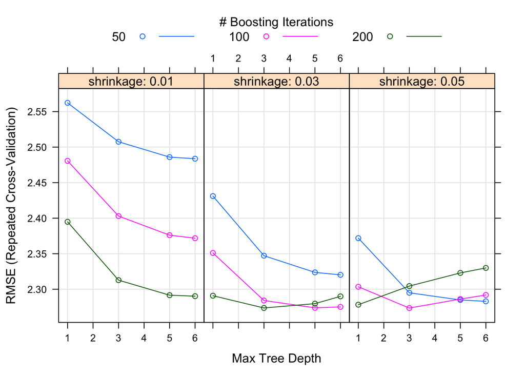

```r
plot(gbm_fit_1)
```

RMSE was used to select the optimal model using the smallest value. The final values used for the model were number of trees = 100, interaction depth = 3, shrinkage = 0.05 with keeping min observations per leaf = 10

## Comparison

### Training

The performance values compared on the “TRAINING” data:

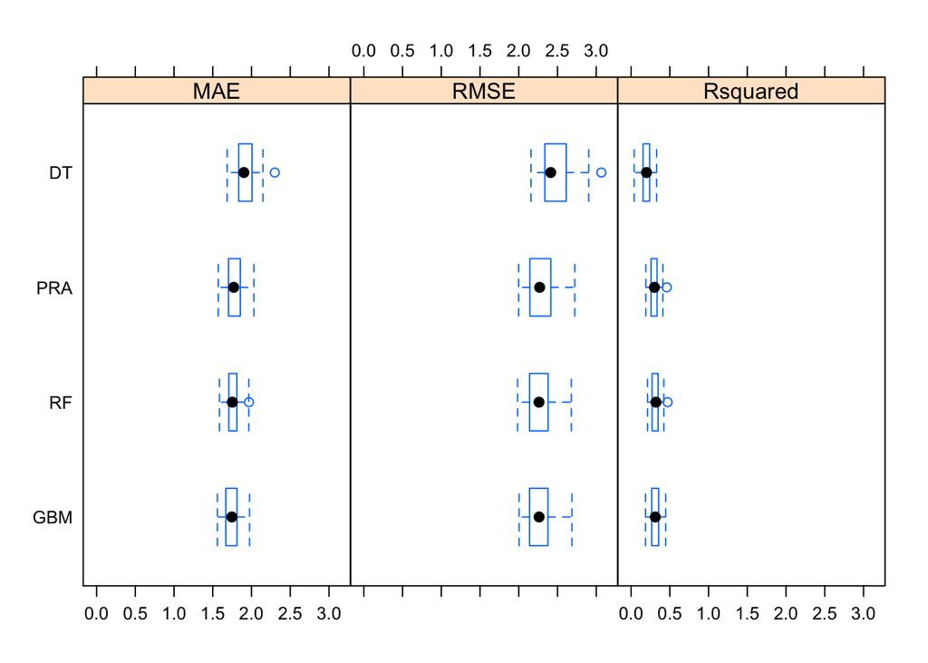

```r
bwplot(resamples(list(PRA=pra_fit_1, DT=dt_fit_1_30, RF=rf_fit_1, GBM= gbm_fit_1)))
```

### Test

Note that the performance values we’ve seen were the results only from training data. Now we will test them on our test data.

First, we create a function for calculating MSE (I’ve then realized there’s a built in one)

```r
# create a function for calculating MSE
mse_calculate <- function(pred,real){
    return <- mean((pred-real)^2)
}
```

```r
pred_pra_1 <- predict(pra_fit_1, data_test_1)
pred_dt_1 <- predict(dt_fit_1_30, data_test_1)
pred_rf_1 <- predict(rf_fit_1, data_test_1)
pred_gbm_1 <- predict(gbm_fit_1, data_test_1)
mse_pra_1 <- mse_calculate(pred_pra_1, data_test_1$G1)
mse_dt_1 <- mse_calculate(pred_dt_1, data_test_1$G1)
mse_rf_1 <- mse_calculate(pred_rf_1, data_test_1$G1)
mse_gbm_1 <- mse_calculate(pred_gbm_1, data_test_1$G1)

MSE_1 <- data.table(mse_pra_1,mse_dt_1,mse_rf_1,mse_gbm_1)
```

```r
MSE_1
```

| mse_pra_1 | mse_dt_1 | mse_rf_1 | mse_gbm_1 |
| --- | --- | --- | --- |
| 5.583059 | 6.302627 | 5.250776 | 5.458759 |

We can see that: Random forest has the least error, then gradient bossting follows it with a similar error result to penalized regression. Decision tree performed much worse then the others.

# Breast Cancer Data

We first modify our data a little more.

```r
# Remove V1 i.e. ID
data_2 <- data_2  %>% select(-V1)
# DATA 1 splitting
set.seed(1)
# test-train index
index_2 <- createDataPartition(y = data_2$V2, p = .75, list = FALSE)
# create the split
data_train_2 <- data_2[index_2,]
data_test_2 <- data_2[-index_2,]
```

## Penalized Regression

```r
# TRUE GLM
set.seed(1)
grid_pra_2 <- expand.grid(lambda = c(0.001,0.005,0.01,0.05,0.1), alpha=1)

pra_fit_2 <- train(V2 ~ .,
                 data = data_train_2,
                 method = "glmnet",
                 tuneGrid = grid_pra_2,
                 trControl = fit_control,
                  preProcess=c("center","scale"))
```

Let’s see the results:

```r
pra_fit_2
```

```
## glmnet
##
## 427 samples
##  30 predictor
##   2 classes: 'B', 'M'
##
## Pre-processing: centered (30), scaled (30)
## Resampling: Cross-Validated (5 fold, repeated 10 times)
## Summary of sample sizes: 342, 342, 341, 342, 341, 341, ...
## Resampling results across tuning parameters:
##
##   lambda  Accuracy   Kappa
##   0.001   0.9730830  0.9422064
##   0.005   0.9709707  0.9374087
##   0.010   0.9693264  0.9334970
##   0.050   0.9604260  0.9132389
##   0.100   0.9369863  0.8601351
##
## Tuning parameter 'alpha' was held constant at a value of 1
## Accuracy was used to select the optimal model using the largest value.
## The final values used for the model were alpha = 1 and lambda = 0.001.
```

Tuning parameter ‘alpha’ was held constant at a value of 1 Accuracy was used to select the optimal model using the largest value. The final values used for the model were alpha = 1 and lambda = 0.001.

## Decision Tree

```r
# DATA 2 DECISION TREE
set.seed(1)
# we create our grid with 10 complexity parameters
# we do min # of instances at terminal node by hand because the tuneGrid of rpart does not support it.

grid_dt_2 <- expand.grid(cp = c(0.0001,0.001,0.005,0.01,0.05))

dt_fit_2_10 <- train(V2 ~ .,
                 data = data_train_2,
                 method = "rpart",
                 tuneGrid = grid_dt_2,
                 control = rpart.control(minbucket=c(10)),
                 trControl = fit_control)

dt_fit_2_20 <- train(V2 ~ .,
                 data = data_train_2,
                 method = "rpart",
                 tuneGrid = grid_dt_2,
                 control = rpart.control(minbucket=c(20)),
                 trControl = fit_control)

dt_fit_2_30 <- train(V2 ~ .,
                 data = data_train_2,
                 method = "rpart",
                 tuneGrid = grid_dt_2,
                 control = rpart.control(minbucket=c(30)),
                 trControl = fit_control)
```

```r
dt_fit_2_10
dt_fit_2_20
dt_fit_2_30
```

[output not shown]

We can see that: Accuracy was used to select the optimal model using the largest value. The final value used for the model was cp = 0.001. And the best value for minimum observations for terminal nodes were 10.

## Random Forest

```r
set.seed(1)
# choosing m=sqrt(# all features) or m=log_2(#all features) may be a good starting point = 5,5 or 5,9 this time
grid_rf_2=expand.grid(mtry = c(1,3,5,6,7,10),
                    splitrule = c("gini"),
                    min.node.size = c(5))

rf_fit_2 <- train(V2 ~ ., data = data_train_2,
                 method = "ranger",
                 trControl = fit_control,
                 num.trees=500,
                 tuneGrid = grid_rf_2)
```

```r
rf_fit_2
```

```
## Random Forest
##
## 427 samples
##  30 predictor
##   2 classes: 'B', 'M'
##
## No pre-processing
## Resampling: Cross-Validated (5 fold, repeated 10 times)
## Summary of sample sizes: 342, 342, 341, 342, 341, 341, ...
## Resampling results across tuning parameters:
##
##   mtry  Accuracy   Kappa
##    1    0.9581032  0.9092994
##    3    0.9601797  0.9140538
##    5    0.9585410  0.9105964
##    6    0.9604124  0.9146496
##    7    0.9594850  0.9126622
##   10    0.9594822  0.9128061
##
## Tuning parameter 'splitrule' was held constant at a value of gini
##
## Tuning parameter 'min.node.size' was held constant at a value of 5
## Accuracy was used to select the optimal model using the largest value.
## The final values used for the model were mtry = 6, splitrule = gini
##  and min.node.size = 5.
```

As the theory suggests 6 (the closest number to 5.9 and 5.5) for the choice of #attributes gave us the best accuracy.

## Stochastic Gradient Boosting

```r
# Gradient Boosting
set.seed(1)
grid_gbm_2 <- expand.grid(interaction.depth = c(1, 3, 5, 6),
                        n.trees = c(50,100,200),
                        shrinkage = c(0.01,0.03,0.05),
                        n.minobsinnode = 10)
gbm_fit_2 <- train(V2 ~ ., data = data_train_2,
                 method = "gbm",
                 trControl = fit_control,
                 tuneGrid = grid_gbm_2
                  )
```

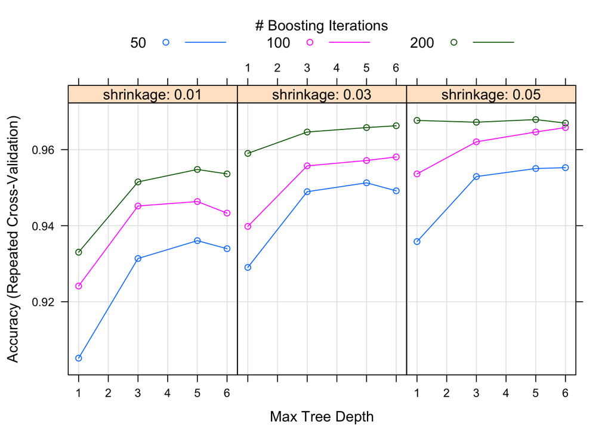

```r
plot(gbm_fit_2)
```

## Comparison

### Training

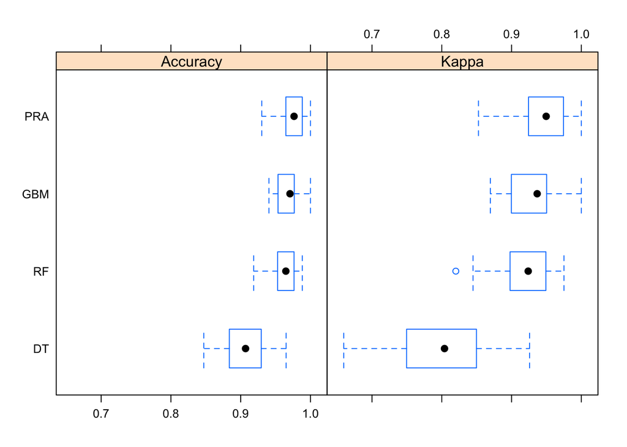

```r
bwplot(resamples(list(PRA=pra_fit_2, DT=dt_fit_2_30, RF=rf_fit_2, GBM= gbm_fit_2)))
```

We can see that PRA is better thann others but it might be because of overfitting. Also decision tree is much worse than others. We’ll be able to comment more after the tests on the test data.

### Test

```r
#function for calculating accuracy
accuracy_calculate <- function(pred,real){
    return(nrow(real[real$V2==pred,])/nrow(real))
}

#predciting test data
pred_pra_2 <- predict(pra_fit_2, data_test_2)
pred_dt_2 <- predict(dt_fit_2_30, data_test_2)
pred_rf_2 <- predict(rf_fit_2, data_test_2)
pred_gbm_2 <- predict(gbm_fit_2, data_test_2)

#calculating accuracy
accuracy_pra_2 <- accuracy_calculate(pred_pra_2,data_test_2)
accuracy_dt_2 <- accuracy_calculate(pred_dt_2,data_test_2)
accuracy_rf_2 <- accuracy_calculate(pred_rf_2,data_test_2)
accuracy_gbm_2 <- accuracy_calculate(pred_gbm_2,data_test_2)

accuracy_results_2 <- data.frame(accuracy_pra_2,accuracy_dt_2,accuracy_rf_2,accuracy_gbm_2)
```

```r
accuracy_results_2
```

| accuracy_pra_2 | accuracy_dt_2 | accuracy_rf_2 | accuracy_gbm_2 |
| --- | --- | --- | --- |
| 0.971831 | 0.915493 | 0.9507042 | 0.9647887 |

We can see that Penalized Regression is really successful with the %97 success rate. Random FOrest and Gradient Boosting model is also close to Penalized Regression however Decision tree performed much worse but still good in the test. The test and training results were similar. So we can say that our models did a good job.

# Online News Popularity Data

```r
# Data is too big so we sample once more
set.seed(1)
index_small_3 <- createDataPartition(y = data_3$shares, p= .05, list=FALSE)
data_small_3 <- data_3[index_small_3,]
data_3_backup <- data_3
data_3 <- data_small_3
```

```r
# Online News Popularity (predicts the total number of shares the news will get) [39k instances]
# DATA 3 splitting
set.seed(1)
# test-train index
index_3 <- createDataPartition(y = data_3$shares, p = .75, list = FALSE)
# create the split
data_train_3 <- data_3[index_3,]
data_test_3 <- data_3[-index_3,]

# As the data is too big we won't repeat the cross-validation
fit_control_3 <- trainControl(method = "cv",
                              number = 10)
```

## Penalized Regression

```r
set.seed(1)
# GLM
grid_pra_3 <- expand.grid(lambda = c(0.01,0.05,0.1,0.5), alpha=1)

pra_fit_3 <- train(shares ~ .,
                 data = data_train_3,
                 method = "glmnet",
                 tuneGrid = grid_pra_3,
                 trControl = fit_control_3)
```

```r
pra_fit_3
```

```
## glmnet
##
## 1489 samples
##   58 predictor
##
## No pre-processing
## Resampling: Cross-Validated (10 fold)
## Summary of sample sizes: 1341, 1341, 1341, 1340, 1340, 1340, ...
## Resampling results across tuning parameters:
##
##   lambda  RMSE      Rsquared    MAE
##   0.01    13207.16  0.02017787  4520.583
##   0.05    13207.16  0.02017787  4520.583
##   0.10    13207.16  0.02017787  4520.583
##   0.50    13207.09  0.02018109  4520.494
##
## Tuning parameter 'alpha' was held constant at a value of 1
## RMSE was used to select the optimal model using the smallest value.
## The final values used for the model were alpha = 1 and lambda = 0.5.
```

## Decision Tree

```r
# DATA 3 DECISION TREE
set.seed(1)
# we create our grid with 10 complexity parameters
# we do min # of instances at terminal node by hand because the tuneGrid of rpart does not support it.

grid_dt_3 <- expand.grid(cp = c(0.00005,0.0001,0.001,0.005,0.01))

dt_fit_3_100 <- train(shares ~ .,
                 data = data_train_3,
                 method = "rpart",
                 tuneGrid = grid_dt_3,
                 control = rpart.control(minbucket=c(100)),
                 trControl = fit_control_3)

dt_fit_3_300 <- train(shares ~ .,
                 data = data_train_3,
                 method = "rpart",
                 tuneGrid = grid_dt_3,
                 control = rpart.control(minbucket=c(300)),
                 trControl = fit_control_3)

dt_fit_3_200 <- train(shares ~ .,
                 data = data_train_3,
                 method = "rpart",
                 tuneGrid = grid_dt_3,
                 control = rpart.control(minbucket=c(200)),
                 trControl = fit_control_3)
```

```r
dt_fit_3_100
```

```
## CART
##
## 1489 samples
##   58 predictor
##
## No pre-processing
## Resampling: Cross-Validated (10 fold)
## Summary of sample sizes: 1341, 1341, 1341, 1340, 1340, 1340, ...
## Resampling results across tuning parameters:
##
##   cp     RMSE      Rsquared     MAE
##   5e-05  12775.46  0.013947881  3951.766
##   1e-04  12773.95  0.013969548  3951.155
##   1e-03  12808.57  0.013563661  3977.347
##   5e-03  12792.92  0.008872812  3971.070
##   1e-02  12806.36  0.008147141  3987.858
##
## RMSE was used to select the optimal model using the smallest value.
## The final value used for the model was cp = 1e-04.
```

```r
dt_fit_3_300
```

```
## CART
##
## 1489 samples
##   58 predictor
##
## No pre-processing
## Resampling: Cross-Validated (10 fold)
## Summary of sample sizes: 1340, 1339, 1340, 1341, 1339, 1341, ...
## Resampling results across tuning parameters:
##
##   cp     RMSE      Rsquared    MAE
##   5e-05  12403.89  0.03011396  3910.411
##   1e-04  12403.89  0.03011396  3910.411
##   1e-03  12403.89  0.03011396  3910.411
##   5e-03  12446.52  0.02284143  3959.247
##   1e-02  12453.20  0.02296830  3958.239
##
## RMSE was used to select the optimal model using the smallest value.
## The final value used for the model was cp = 0.001.
```

```r
dt_fit_3_200
```

```
## CART
##
## 1489 samples
##   58 predictor
##
## No pre-processing
## Resampling: Cross-Validated (10 fold)
## Summary of sample sizes: 1341, 1339, 1340, 1341, 1341, 1339, ...
## Resampling results across tuning parameters:
##
##   cp     RMSE      Rsquared     MAE
##   5e-05  12343.62  0.023488631  3873.524
##   1e-04  12343.62  0.023488631  3873.524
##   1e-03  12355.58  0.021466118  3887.047
##   5e-03  12433.09  0.006701219  3937.724
##   1e-02  12442.41  0.006537784  3941.391
##
## RMSE was used to select the optimal model using the smallest value.
## The final value used for the model was cp = 1e-04.
```

200 is the best among others.The final value used for the model was cp = 1e-04.RMSE was used to select the optimal model using the smallest value.

## Random Forest

```r
set.seed(1)
# choosing m=sqrt(# all features) or m=log_2(#all features) may be a good starting point = 5,5 or 5,9 this time
grid_rf_3=expand.grid(mtry = c(5,6,7,8),
                    splitrule = c("variance","extratrees"),
                    min.node.size = c(5))

rf_fit_3 <- train(shares ~ ., data = data_train_3,
                 method = "ranger",
                 trControl = fit_control_3,
                 num.trees= 500,
                 tuneGrid = grid_rf_3)
```

```r
rf_fit_3
```

```
## Random Forest
##
## 1489 samples
##   58 predictor
##
## No pre-processing
## Resampling: Cross-Validated (10 fold)
## Summary of sample sizes: 1341, 1341, 1341, 1340, 1340, 1340, ...
## Resampling results across tuning parameters:
##
##   mtry  splitrule   RMSE      Rsquared    MAE
##   5     variance    12660.05  0.05549849  3976.204
##   5     extratrees  12775.62  0.02692830  3928.742
##   6     variance    12598.47  0.06938633  3992.374
##   6     extratrees  12805.73  0.02340957  3938.532
##   7     variance    12643.36  0.06582700  3970.305
##   7     extratrees  12885.44  0.02683423  3936.836
##   8     variance    12704.26  0.05959264  4039.282
##   8     extratrees  12918.34  0.02623971  4000.052
##
## Tuning parameter 'min.node.size' was held constant at a value of 5
## RMSE was used to select the optimal model using the smallest value.
## The final values used for the model were mtry = 6, splitrule = variance
##  and min.node.size = 5.
```

## Stochastic Gradient Boosting

```r
# Gradient Boosting
set.seed(1)
grid_gbm_3 <- expand.grid(interaction.depth = c(1, 3, 5, 6),
                        n.trees = c(50,100,200),
                        shrinkage = c(0.001,0.005,0.01), # cok instance varsa 10k+ falan 0.1 denenebilir
                        n.minobsinnode = 10)
gbm_fit_3 <- train(shares ~ ., data = data_train_3,
                 method = "gbm",
                 trControl = fit_control_3,
                 tuneGrid = grid_gbm_3
                  )
```

```r
gbm_fit_3
```

```
## Stochastic Gradient Boosting
##
## 1489 samples
##   58 predictor
##
## No pre-processing
## Resampling: Cross-Validated (10 fold)
## Summary of sample sizes: 1341, 1341, 1341, 1340, 1340, 1340, ...
## Resampling results across tuning parameters:
##
##   shrinkage  interaction.depth  n.trees  RMSE      Rsquared     MAE
##   0.001      1                   50      12540.94  0.009617954  3886.440
##   0.001      1                  100      12536.90  0.009913320  3881.230
##   0.001      1                  200      12529.50  0.011381132  3874.780
##   0.001      3                   50      12532.80  0.027056736  3881.405
##   0.001      3                  100      12523.53  0.021027811  3875.812
##   0.001      3                  200      12507.18  0.023123003  3862.698
##   0.001      5                   50      12531.57  0.029466631  3876.612
##   0.001      5                  100      12516.56  0.031415688  3864.490
##   0.001      5                  200      12496.31  0.030312956  3844.431
##   0.001      6                   50      12529.42  0.031276215  3875.467
##   0.001      6                  100      12514.57  0.033079594  3865.244
##   0.001      6                  200      12492.12  0.032125256  3848.861
##   0.005      1                   50      12527.95  0.009916472  3874.930
##   0.005      1                  100      12523.26  0.011090222  3863.355
##   0.005      1                  200      12525.64  0.016027731  3845.574
##   0.005      3                   50      12514.63  0.024801988  3874.125
##   0.005      3                  100      12505.13  0.022451470  3854.183
##   0.005      3                  200      12535.87  0.026862714  3849.237
##   0.005      5                   50      12497.77  0.029274039  3842.490
##   0.005      5                  100      12492.01  0.028644973  3820.958
##   0.005      5                  200      12519.24  0.031216480  3808.382
##   0.005      6                   50      12489.81  0.032841912  3833.294
##   0.005      6                  100      12473.82  0.029662127  3811.534
##   0.005      6                  200      12499.95  0.035150893  3785.558
##   0.010      1                   50      12516.81  0.011923248  3861.611
##   0.010      1                  100      12528.93  0.015715232  3855.196
##   0.010      1                  200      12568.50  0.020764530  3855.051
##   0.010      3                   50      12493.63  0.028482596  3842.897
##   0.010      3                  100      12530.21  0.027915656  3828.772
##   0.010      3                  200      12718.09  0.029464844  3896.780
##   0.010      5                   50      12483.79  0.027445460  3824.473
##   0.010      5                  100      12533.22  0.028759932  3813.529
##   0.010      5                  200      12692.53  0.030072921  3861.802
##   0.010      6                   50      12480.46  0.030479566  3811.901
##   0.010      6                  100      12508.90  0.036588085  3817.776
##   0.010      6                  200      12634.85  0.036171428  3853.491
##
## Tuning parameter 'n.minobsinnode' was held constant at a value of 10
## RMSE was used to select the optimal model using the smallest value.
## The final values used for the model were n.trees = 100, interaction.depth =
##  6, shrinkage = 0.005 and n.minobsinnode = 10.
```

## Comparison

### Training

The performance values compared on the “TRAINING” data:

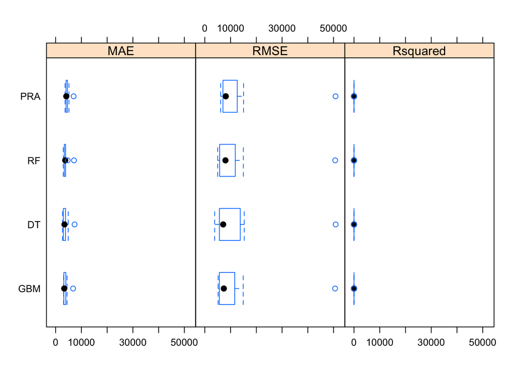

```r
bwplot(resamples(list(PRA=pra_fit_3, DT=dt_fit_3_200, RF=rf_fit_3, GBM= gbm_fit_3)))
```

We see that squared errors are similar but DT has a bigger confidence interval. ### Test

```r
pred_pra_3 <- predict(pra_fit_3,data_test_3)
pred_dt_3 <- predict(dt_fit_3_200,data_test_3)
pred_rf_3 <- predict(rf_fit_3,data_test_3)
pred_gbm_3 <- predict(gbm_fit_3,data_test_3)
```

```r
MSE_3 <- data.table(
RMSE(pred_pra_3,data_test_3$shares),
RMSE(pred_dt_3,data_test_3$shares),
RMSE(pred_rf_3,data_test_3$shares),
RMSE(pred_gbm_3,data_test_3$shares))
colnames(MSE_3) <- c('PRA', 'DT', 'RF', 'GBM')
MSE_3
```

| PRA | DT | RF | GBM |
| --- | --- | --- | --- |
| 7028.22 | 6563.607 | 6683.407 | 6398.358 |

We see the errors in test are lower than train. It might be because of the extreme values in the train set. We can say that the methods are working well. Gradient Boost Model did a little better than the others and Penalized Approach was the forst among others.

# Bankruptcy

We need to handle NA’s and ?’s in the data first. I will replace missing values with the columns mean. Also recall that this dataset is highly imbalanced. So we will need to take some more actions.

```r
custom_func <- function(x) {
  return (ifelse(x=='?',NA,as.numeric(x)))
}
#turn elements from char to doubles and ? to NA
data_4 <- suppressWarnings(apply(data_4,2,custom_func))
# replace NA with mean of that column
suppressWarnings(for(i in 1:ncol(data_4)){
  data_4[is.na(data_4[,i]), i] <- mean(data_4[,i], na.rm = TRUE)
})
data_4 <- select(data.frame(data_4),-id)
data_4$class <- as.factor(data_4$class)
```

```r
fit_control_4 = trainControl(method = "cv",
                           number = 5)
```

```r
set.seed(1)
# test-train index
index_4 <- createDataPartition(y = data_4$class, p = .75, list = FALSE)
# create the split
im_data_train_4 <- data_4[index_4,] #imbalanced set (didnt put the details but training with this dataset created algortihms that only predicts the class with more elements.)
data_test_4 <- data_4[-index_4,]
#DOWN SAMPLING
data_train_4 <- downSample(select(im_data_train_4,-class), im_data_train_4$class, list = FALSE, yname='class')
summary(data_train_4$class)
```

[output not shown]

## Penalized Regression

```r
# GLM with downsampling
set.seed(1)
grid_pra_4 <- expand.grid(lambda = c(0.001,0.00001,0.000001), alpha=1)
# grid_pra_4 <- expand.grid(lambda = 0.1, alpha=1)

pra_fit_4 <- train(class ~ .,
                 data = data_train_4,
                 method = "glmnet",
                 tuneGrid = grid_pra_4,
                 trControl = fit_control_4)
pra_fit_4
```

```
## glmnet
##
## 774 samples
##  64 predictor
##   2 classes: '0', '1'
##
## No pre-processing
## Resampling: Cross-Validated (5 fold)
## Summary of sample sizes: 619, 619, 620, 619, 619
## Resampling results across tuning parameters:
##
##   lambda  Accuracy   Kappa
##   1e-06   0.7066695  0.4132372
##   1e-05   0.7066695  0.4132372
##   1e-03   0.6835023  0.3669633
##
## Tuning parameter 'alpha' was held constant at a value of 1
## Accuracy was used to select the optimal model using the largest value.
## The final values used for the model were alpha = 1 and lambda = 1e-05.
```

## Decision Tree

```r
# DATA 4 DECISION TREE
set.seed(1)
# we create our grid with 10 complexity parameters
# we do min # of instances at terminal node by hand because the tuneGrid of rpart does not support it.

grid_dt_4 <- expand.grid(cp = c(0.001,0.01,0.05))

dt_fit_4_10 <- train(class ~ .,
                 data = data_train_4,
                 method = "rpart",
                 tuneGrid = grid_dt_4,
                 control = rpart.control(minbucket=c(10)),
                 trControl = fit_control_4)

dt_fit_4_50 <- train(class ~ .,
                 data = data_train_4,
                 method = "rpart",
                 tuneGrid = grid_dt_4,
                 control = rpart.control(minbucket=c(50)),
                 trControl = fit_control_4)

dt_fit_4_100 <- train(class ~ .,
                 data = data_train_4,
                 method = "rpart",
                 tuneGrid = grid_dt_4,
                 control = rpart.control(minbucket=c(100)),
                 trControl = fit_control_4)
```

```r
dt_fit_4_10
```

```
## CART
##
## 774 samples
##  64 predictor
##   2 classes: '0', '1'
##
## No pre-processing
## Resampling: Cross-Validated (5 fold)
## Summary of sample sizes: 619, 619, 620, 619, 619
## Resampling results across tuning parameters:
##
##   cp     Accuracy   Kappa
##   0.001  0.7054881  0.4107003
##   0.010  0.7080184  0.4159467
##   0.050  0.7106158  0.4209518
##
## Accuracy was used to select the optimal model using the largest value.
## The final value used for the model was cp = 0.05.
```

```r
dt_fit_4_50
```

```
## CART
##
## 774 samples
##  64 predictor
##   2 classes: '0', '1'
##
## No pre-processing
## Resampling: Cross-Validated (5 fold)
## Summary of sample sizes: 618, 620, 620, 619, 619
## Resampling results across tuning parameters:
##
##   cp     Accuracy   Kappa
##   0.001  0.6953013  0.3905740
##   0.010  0.6953013  0.3905740
##   0.050  0.6834717  0.3667431
##
## Accuracy was used to select the optimal model using the largest value.
## The final value used for the model was cp = 0.01.
```

```r
dt_fit_4_100
```

```
## CART
##
## 774 samples
##  64 predictor
##   2 classes: '0', '1'
##
## No pre-processing
## Resampling: Cross-Validated (5 fold)
## Summary of sample sizes: 619, 619, 620, 619, 619
## Resampling results across tuning parameters:
##
##   cp     Accuracy   Kappa
##   0.001  0.6576456  0.3156652
##   0.010  0.6499036  0.2994574
##   0.050  0.6525010  0.3046522
##
## Accuracy was used to select the optimal model using the largest value.
## The final value used for the model was cp = 0.001.
```

## Random Forest

```r
set.seed(1)
# choosing m=sqrt(# all features) or m=log_2(#all features) may be a good starting point =6 or 8 this time
grid_rf_4 = expand.grid(mtry = c(6,7,8),
                    splitrule = c("gini"),
                    min.node.size = c(5))

rf_fit_4 <- train(class ~ ., data = data_train_4,
                 method = "ranger",
                 trControl = fit_control_4,
                 num.trees=500,
                 tuneGrid = grid_rf_4)
```

```r
rf_fit_4
```

```
## Random Forest
##
## 774 samples
##  64 predictor
##   2 classes: '0', '1'
##
## No pre-processing
## Resampling: Cross-Validated (5 fold)
## Summary of sample sizes: 619, 619, 620, 619, 619
## Resampling results across tuning parameters:
##
##   mtry  Accuracy   Kappa
##   6     0.7687055  0.5373396
##   7     0.7751822  0.5503801
##   8     0.7906745  0.5813067
##
## Tuning parameter 'splitrule' was held constant at a value of gini
##
## Tuning parameter 'min.node.size' was held constant at a value of 5
## Accuracy was used to select the optimal model using the largest value.
## The final values used for the model were mtry = 8, splitrule = gini
##  and min.node.size = 5.
```

## Stochastic Gradient Boosting

```r
# Gradient Boosting
set.seed(1)
grid_gbm_4 <- expand.grid(interaction.depth = c(1, 3, 6),
                        n.trees = c(50,100,200),
                        shrinkage = c(0.01,0.03,0.05),
                        n.minobsinnode = 10)
gbm_fit_4 <- train(class ~ ., data = data_train_4,
                 method = "gbm",
                 trControl = fit_control_4,
                 tuneGrid = grid_gbm_4
                  )
```

```r
gbm_fit_4
```

```
## Stochastic Gradient Boosting
##
## 774 samples
##  64 predictor
##   2 classes: '0', '1'
##
## No pre-processing
## Resampling: Cross-Validated (5 fold)
## Summary of sample sizes: 619, 619, 620, 619, 619
## Resampling results across tuning parameters:
##
##   shrinkage  interaction.depth  n.trees  Accuracy   Kappa
##   0.01       1                   50      0.7054462  0.4107569
##   0.01       1                  100      0.7093088  0.4184877
##   0.01       1                  200      0.7339087  0.4677046
##   0.01       3                   50      0.7571596  0.5141882
##   0.01       3                  100      0.7636112  0.5271110
##   0.01       3                  200      0.7726435  0.5452677
##   0.01       6                   50      0.7687809  0.5375854
##   0.01       6                  100      0.7739254  0.5478468
##   0.01       6                  200      0.7842564  0.5684547
##   0.03       1                   50      0.7222455  0.4443253
##   0.03       1                  100      0.7429661  0.4858293
##   0.03       1                  200      0.7571680  0.5143369
##   0.03       3                   50      0.7688060  0.5375755
##   0.03       3                  100      0.7868622  0.5736775
##   0.03       3                  200      0.7971680  0.5942765
##   0.03       6                   50      0.7752241  0.5503591
##   0.03       6                  100      0.7984667  0.5968619
##   0.03       6                  200      0.8036196  0.6071543
##   0.05       1                   50      0.7274654  0.4547611
##   0.05       1                  100      0.7442648  0.4884812
##   0.05       1                  200      0.7545790  0.5091444
##   0.05       3                   50      0.7636280  0.5271679
##   0.05       3                  100      0.7894177  0.5787489
##   0.05       3                  200      0.8062003  0.6123317
##   0.05       6                   50      0.7777796  0.5555521
##   0.05       6                  100      0.8010222  0.6020360
##   0.05       6                  200      0.8074654  0.6148238
##
## Tuning parameter 'n.minobsinnode' was held constant at a value of 10
## Accuracy was used to select the optimal model using the largest value.
## The final values used for the model were n.trees = 200, interaction.depth =
##  6, shrinkage = 0.05 and n.minobsinnode = 10.
```

Tuning parameter ‘n.minobsinnode’ was held constant at a value of 10 Accuracy was used to select the optimal model using the largest value. The final values used for the model were n.trees = 200, interaction.depth = 6, shrinkage = 0.05 and n.minobsinnode = 10.

## Comparison

### Training

The performance values compared on the “TRAINING” data:

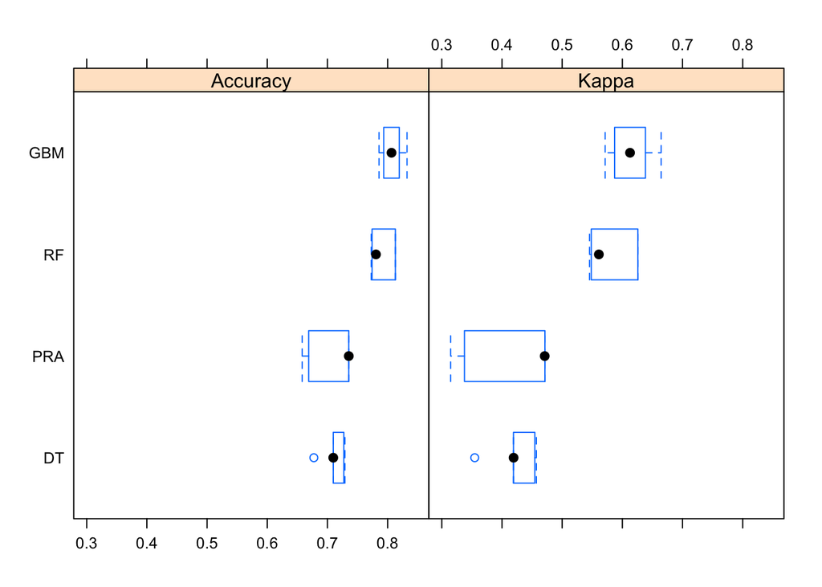

```r
bwplot(resamples(list(PRA=pra_fit_4, DT=dt_fit_4_10, RF=rf_fit_4, GBM= gbm_fit_4)))
```

Algorithms are not very successful this time Penalized Regression with Decision Tree did pretty worse. Random Forest is pretty close to GBM but we can say that GBM outperform all other approaches. ### Test

```r
pred_pra_4 <- predict(pra_fit_4,data_test_4)
pred_dt_4 <- predict(dt_fit_4_10,data_test_4)
pred_rf_4 <- predict(rf_fit_4,data_test_4)
pred_gbm_4 <- predict(gbm_fit_4,data_test_4)
```

```r
accuracy_calculate_4 <- function(pred,real){
    return(nrow(real[real$class==pred,])/nrow(real))
}
```

```r
acc_4 <- data.table(
accuracy_calculate_4(pred_pra_4,data_test_4),
accuracy_calculate_4(pred_dt_4,data_test_4),
accuracy_calculate_4(pred_rf_4,data_test_4),
accuracy_calculate_4(pred_gbm_4,data_test_4))
colnames(acc_4) <- c('PRA', 'DT', 'RF', 'GBM')
acc_4
```

| PRA | DT | RF | GBM |
| --- | --- | --- | --- |
| 0.7535758 | 0.7478545 | 0.7658357 | 0.8026154 |